# Turkey in Comparison: GDP, Education and Inequality Against Neighbours and Europe (1990-2020)

Omer GIZBILI & Kaan Mert SEVINC

2026-04-28

```r
# Core libraries
library(tidyverse)  # data manipulation and visualization
library(knitr)      # report generation
library(kableExtra) # formatted tables
library(scales)     # axis formatting
library(zoo)        # linear interpolation for missing values
```

# 1 Introduction

## 1.1 Context

This project analyzes Turkey’s economic and social development between 1990 and 2020, comparing it to its direct neighbours and five major European economies. We focus on three key indicators: GDP per capita, mean years of schooling, and the Gini coefficient (income inequality).

**Research question:** *How does Turkey’s economic development and social indicators compare to its neighbours and major European economies between 1990 and 2020?*

## 1.2 Data Sources

We use three datasets from **Our World in Data**, all sourced from major international institutions:

[output not shown]

## 1.3 Description of Variables

- **GDP per capita**: Average economic output per person, adjusted for inflation and purchasing power parity (PPP). Expressed in constant 2021 international dollars.
- **Mean years of schooling**: Average number of years of education received by people aged 25 and older.
- **Gini coefficient**: Measures income inequality on a scale from 0 (perfect equality) to 1 (maximum inequality).

# 2 Methodology

## 2.1 Data Loading

```r
# Load the three raw CSV files
# Paths are relative to the rapport/ folder
gdp_raw  <- read_csv("../data/raw/gdp-per-capita-worldbank.csv")
edu_raw  <- read_csv("../data/raw/mean-years-of-schooling-long-run.csv")
gini_raw <- read_csv("../data/raw/economic-inequality-gini-index.csv")
```

## 2.2 Data Characterization

```r
# Overview of each dataset: dimensions, countries, time span
datasets <- list(
  "GDP per capita"       = gdp_raw,
  "Years of schooling"   = edu_raw,
  "Gini coefficient"     = gini_raw
)

carac <- map_dfr(datasets, function(df) {
  tibble(
    Rows      = nrow(df),
    Columns   = ncol(df),
    Countries = n_distinct(df$Entity),
    Year_min  = min(df$Year, na.rm = TRUE),
    Year_max  = max(df$Year, na.rm = TRUE)
  )
}, .id = "Dataset")

kable(carac, caption = "Characterization of the three datasets") %>%
  kable_styling(bootstrap_options = c("striped", "hover"))
```

Characterization of the three datasets

| Dataset | Rows | Columns | Countries | Year_min | Year_max |
| --- | --- | --- | --- | --- | --- |
| GDP per capita | 7240 | 5 | 212 | 1990 | 2024 |
| Years of schooling | 3699 | 4 | 153 | 1870 | 2020 |
| Gini coefficient | 2389 | 5 | 183 | 1963 | 2025 |

## 2.3 Data Quality Assessment

```r
# Missing values per dataset
missing_report <- map_dfr(datasets, function(df) {
  df %>%
    summarise(across(everything(), ~ sum(is.na(.)))) %>%
    pivot_longer(everything(),
                 names_to  = "Variable",
                 values_to = "Missing_values")
}, .id = "Dataset")

kable(missing_report, caption = "Missing values per variable") %>%
  kable_styling(bootstrap_options = c("striped", "hover"))
```

Missing values per variable

| Dataset | Variable | Missing_values |
| --- | --- | --- |
| GDP per capita | Entity | 0 |
| GDP per capita | Code | 0 |
| GDP per capita | Year | 0 |
| GDP per capita | GDP per capita | 0 |
| GDP per capita | World region according to OWID | 455 |
| Years of schooling | Entity | 0 |
| Years of schooling | Code | 0 |
| Years of schooling | Year | 0 |
| Years of schooling | Average years of schooling | 0 |
| Gini coefficient | Entity | 0 |
| Gini coefficient | Code | 109 |
| Gini coefficient | Year | 0 |
| Gini coefficient | Gini coefficient | 0 |
| Gini coefficient | World region according to OWID | 109 |

## 2.4 Data Cleaning and Integration

### 2.4.1 Step 1 — Build the complete dataset (left_join)

```r
# We join the three datasets on Entity and Year
# left_join keeps all GDP rows and adds schooling/gini where available
# This preserves all country-year combinations from the GDP dataset
complete_data <- gdp_raw %>%
  rename(gdp = `GDP per capita`) %>%
  select(Entity, Year, gdp) %>%
  left_join(
    edu_raw %>%
      rename(schooling = `Average years of schooling`) %>%
      select(Entity, Year, schooling),
    by = c("Entity", "Year")
  ) %>%
  left_join(
    gini_raw %>%
      rename(gini = `Gini coefficient`) %>%
      select(Entity, Year, gini),
    by = c("Entity", "Year")
  )

cat("Complete dataset dimensions:", nrow(complete_data), "rows x", ncol(complete_data), "columns\n")
```

```
## Complete dataset dimensions: 7240 rows x 5 columns
```

```r
cat("Countries:", n_distinct(complete_data$Entity), "\n")
```

```
## Countries: 212
```

```r
cat("Years:", min(complete_data$Year), "to", max(complete_data$Year), "\n")
```

```
## Years: 1990 to 2024
```

### 2.4.2 Step 2 — Define the country list

```r
# Turkey + 8 neighbours + 5 major European economies
countries <- c(
  "Turkey",
  # Neighbours
  "Greece", "Bulgaria", "Georgia", "Armenia", "Azerbaijan",
  "Iran", "Iraq", "Syria",
  # Major European economies
  "Spain", "United Kingdom", "France", "Germany", "Italy"
)

cat("Total countries selected:", length(countries), "\n")
```

```
## Total countries selected: 14
```

### 2.4.3 Step 3 — Filter the analysis dataset

```r
# Keep only selected countries and years 1990-2020
analysis_data <- complete_data %>%
  filter(Entity %in% countries,
         Year >= 1990, Year <= 2020)

cat("Analysis dataset:", nrow(analysis_data), "rows\n")
```

```
## Analysis dataset: 434 rows
```

### 2.4.4 Step 4 — Data coverage per country

```r
# How many non-missing observations per country per variable?
coverage <- analysis_data %>%
  group_by(Entity) %>%
  summarise(
    n_gdp       = sum(!is.na(gdp)),
    n_schooling = sum(!is.na(schooling)),
    n_gini      = sum(!is.na(gini))
  ) %>%
  arrange(desc(n_gdp))

kable(coverage,
      caption = "Data coverage per country (1990-2020)",
      col.names = c("Country", "GDP observations", "Schooling observations", "Gini observations")) %>%
  kable_styling(bootstrap_options = c("striped", "hover"))
```

Data coverage per country (1990-2020)

| Country | GDP observations | Schooling observations | Gini observations |
| --- | --- | --- | --- |
| Armenia | 31 | 2 | 21 |
| Azerbaijan | 31 | 0 | 6 |
| Bulgaria | 31 | 7 | 16 |
| France | 31 | 7 | 26 |
| Georgia | 31 | 0 | 25 |
| Germany | 31 | 7 | 30 |
| Greece | 31 | 7 | 21 |
| Iran | 31 | 7 | 16 |
| Iraq | 31 | 7 | 2 |
| Italy | 31 | 7 | 24 |
| Spain | 31 | 7 | 27 |
| Syria | 31 | 7 | 4 |
| Turkey | 31 | 7 | 20 |
| United Kingdom | 31 | 7 | 31 |

**Observations:**

- GDP data is complete for all 14 countries (31 observations each).
- Schooling data is available roughly every 5 years; Azerbaijan and Georgia have no data.
- Gini data is highly incomplete for Iraq (2 obs.), Syria (4 obs.), and Azerbaijan (6 obs.).

# 3 Analysis

## 3.1 GDP per Capita

### 3.1.1 All countries

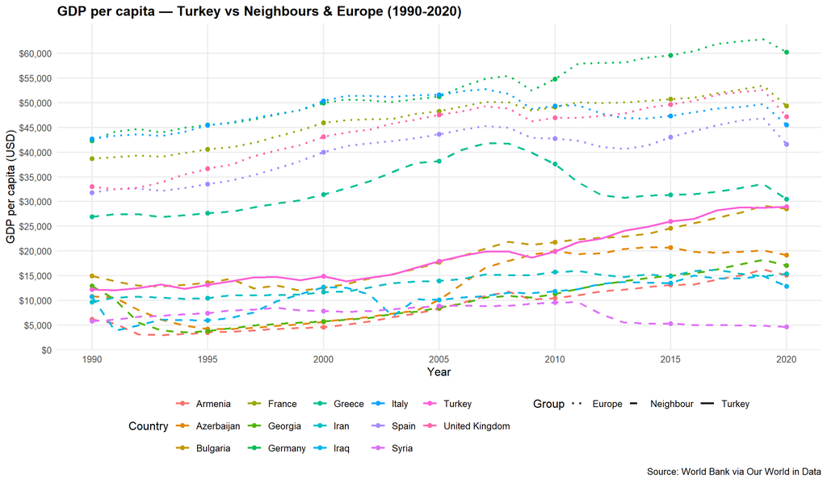

```r
# All 14 countries, linetype distinguishes groups
# Turkey is highlighted with a solid line
analysis_data %>%
  mutate(group = ifelse(Entity == "Turkey", "Turkey",
                 ifelse(Entity %in% c("Greece", "Bulgaria", "Georgia",
                                       "Armenia", "Azerbaijan", "Iran",
                                       "Iraq", "Syria"),
                        "Neighbour", "Europe"))) %>%
  ggplot(aes(x = Year, y = gdp, color = Entity, linetype = group)) +
  geom_line(linewidth = 1) +
  geom_point(data = . %>% filter(Year %in% c(1990, 1995, 2000, 2005, 2010, 2015, 2020)),
             size = 2) +
  scale_y_continuous(labels = label_dollar(big.mark = ","),
                     breaks = seq(0, 60000, by = 5000)) +
  scale_x_continuous(breaks = seq(1990, 2020, by = 5)) +
  scale_linetype_manual(values = c("Turkey" = "solid",
                                   "Neighbour" = "dashed",
                                   "Europe" = "dotted")) +
  labs(title   = "GDP per capita — Turkey vs Neighbours & Europe (1990-2020)",
       x       = "Year", y = "GDP per capita (USD)",
       color   = "Country", linetype = "Group",
       caption = "Source: World Bank via Our World in Data") +
  theme_minimal(base_size = 12) +
  theme(plot.title       = element_text(face = "bold"),
        legend.position  = "bottom",
        panel.grid.minor = element_blank())
```

### 3.1.2 Turkey vs Neighbours

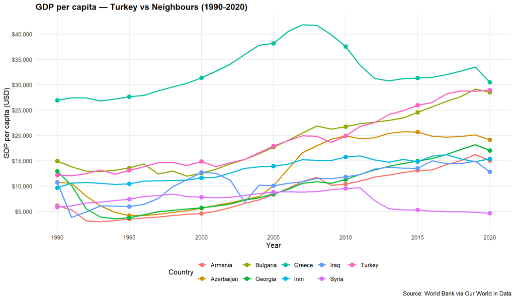

```r
analysis_data %>%
  filter(Entity %in% c("Turkey", "Greece", "Bulgaria", "Georgia",
                        "Armenia", "Azerbaijan", "Iran", "Iraq", "Syria")) %>%
  ggplot(aes(x = Year, y = gdp, color = Entity)) +
  geom_line(linewidth = 1) +
  geom_point(data = . %>% filter(Year %in% c(1990, 1995, 2000, 2005, 2010, 2015, 2020)),
             size = 3) +
  scale_y_continuous(labels = label_dollar(big.mark = ","),
                     breaks = seq(0, 40000, by = 5000)) +
  scale_x_continuous(breaks = seq(1990, 2020, by = 5)) +
  labs(title   = "GDP per capita — Turkey vs Neighbours (1990-2020)",
       x       = "Year", y = "GDP per capita (USD)", color = "Country",
       caption = "Source: World Bank via Our World in Data") +
  theme_minimal(base_size = 12) +
  theme(plot.title       = element_text(face = "bold"),
        legend.position  = "bottom",
        panel.grid.minor = element_blank())
```

### 3.1.3 Turkey vs Europe

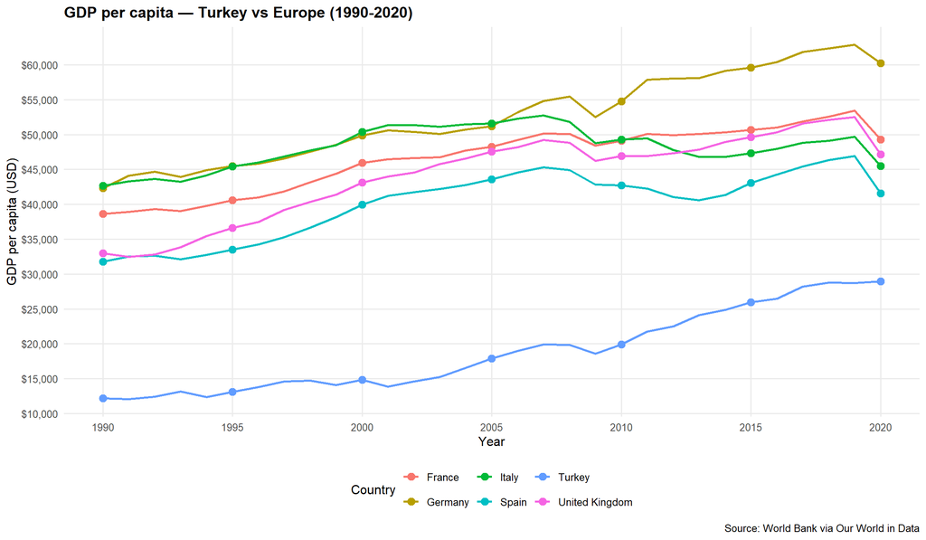

```r
analysis_data %>%
  filter(Entity %in% c("Turkey", "Spain", "United Kingdom",
                        "France", "Germany", "Italy")) %>%
  ggplot(aes(x = Year, y = gdp, color = Entity)) +
  geom_line(linewidth = 1) +
  geom_point(data = . %>% filter(Year %in% c(1990, 1995, 2000, 2005, 2010, 2015, 2020)),
             size = 3) +
  scale_y_continuous(labels = label_dollar(big.mark = ","),
                     breaks = seq(0, 60000, by = 5000)) +
  scale_x_continuous(breaks = seq(1990, 2020, by = 5)) +
  labs(title   = "GDP per capita — Turkey vs Europe (1990-2020)",
       x       = "Year", y = "GDP per capita (USD)", color = "Country",
       caption = "Source: World Bank via Our World in Data") +
  theme_minimal(base_size = 12) +
  theme(plot.title       = element_text(face = "bold"),
        legend.position  = "bottom",
        panel.grid.minor = element_blank())
```

## 3.2 Mean Years of Schooling

### 3.2.1 All countries

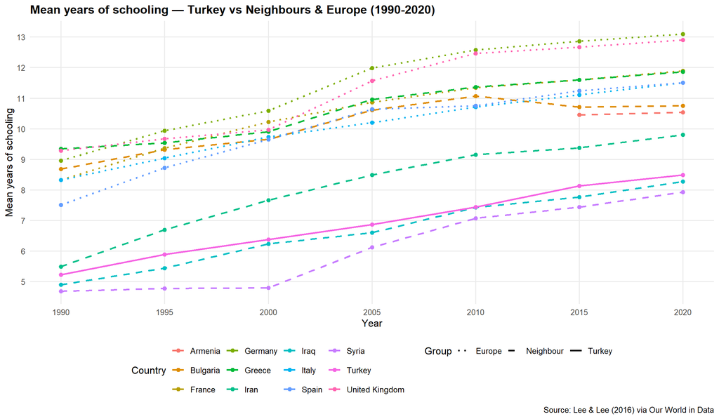

```r
analysis_data %>%
  filter(!is.na(schooling)) %>%
  mutate(group = ifelse(Entity == "Turkey", "Turkey",
                 ifelse(Entity %in% c("Greece", "Bulgaria", "Georgia",
                                       "Armenia", "Azerbaijan", "Iran",
                                       "Iraq", "Syria"),
                        "Neighbour", "Europe"))) %>%
  ggplot(aes(x = Year, y = schooling, color = Entity, linetype = group)) +
  geom_line(linewidth = 1) +
  geom_point(size = 2) +
  scale_y_continuous(breaks = seq(0, 15, by = 1)) +
  scale_x_continuous(breaks = seq(1990, 2020, by = 5)) +
  scale_linetype_manual(values = c("Turkey" = "solid",
                                   "Neighbour" = "dashed",
                                   "Europe" = "dotted")) +
  labs(title   = "Mean years of schooling — Turkey vs Neighbours & Europe (1990-2020)",
       x       = "Year", y = "Mean years of schooling",
       color   = "Country", linetype = "Group",
       caption = "Source: Lee & Lee (2016) via Our World in Data") +
  theme_minimal(base_size = 12) +
  theme(plot.title       = element_text(face = "bold"),
        legend.position  = "bottom",
        panel.grid.minor = element_blank())
```

### 3.2.2 Turkey vs Neighbours

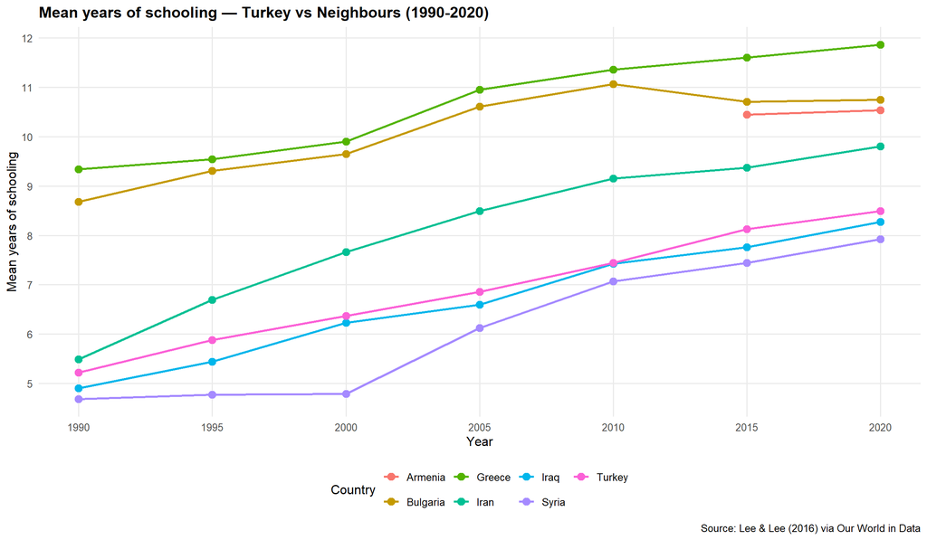

```r
analysis_data %>%
  filter(Entity %in% c("Turkey", "Greece", "Bulgaria", "Georgia",
                        "Armenia", "Azerbaijan", "Iran", "Iraq", "Syria"),
         !is.na(schooling)) %>%
  ggplot(aes(x = Year, y = schooling, color = Entity)) +
  geom_line(linewidth = 1) +
  geom_point(size = 3) +
  scale_y_continuous(breaks = seq(0, 15, by = 1)) +
  scale_x_continuous(breaks = seq(1990, 2020, by = 5)) +
  labs(title   = "Mean years of schooling — Turkey vs Neighbours (1990-2020)",
       x       = "Year", y = "Mean years of schooling", color = "Country",
       caption = "Source: Lee & Lee (2016) via Our World in Data") +
  theme_minimal(base_size = 12) +
  theme(plot.title       = element_text(face = "bold"),
        legend.position  = "bottom",
        panel.grid.minor = element_blank())
```

### 3.2.3 Turkey vs Europe

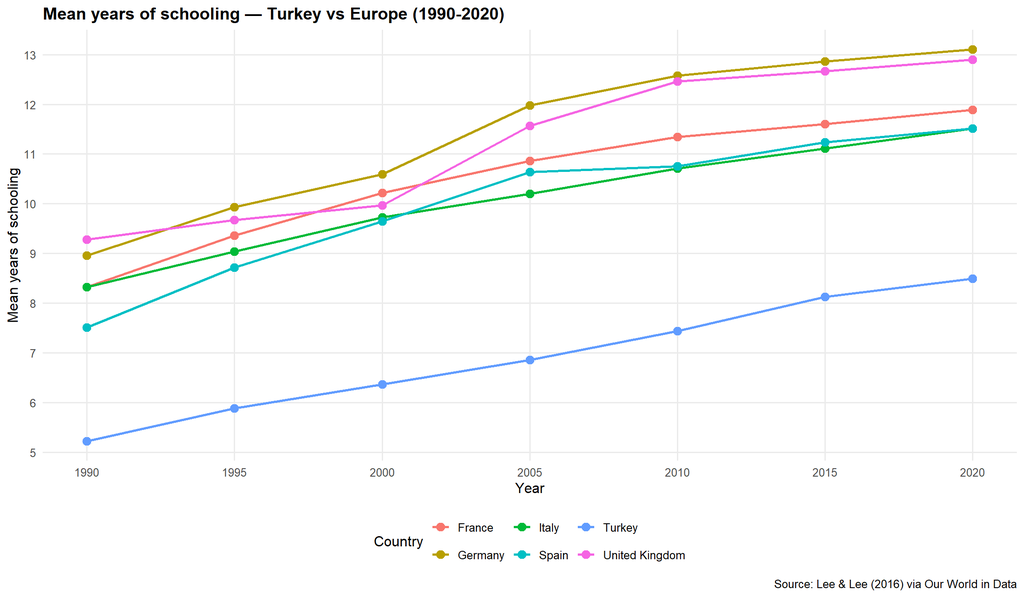

```r
analysis_data %>%
  filter(Entity %in% c("Turkey", "Spain", "United Kingdom",
                        "France", "Germany", "Italy"),
         !is.na(schooling)) %>%
  ggplot(aes(x = Year, y = schooling, color = Entity)) +
  geom_line(linewidth = 1) +
  geom_point(size = 3) +
  scale_y_continuous(breaks = seq(0, 15, by = 1)) +
  scale_x_continuous(breaks = seq(1990, 2020, by = 5)) +
  labs(title   = "Mean years of schooling — Turkey vs Europe (1990-2020)",
       x       = "Year", y = "Mean years of schooling", color = "Country",
       caption = "Source: Lee & Lee (2016) via Our World in Data") +
  theme_minimal(base_size = 12) +
  theme(plot.title       = element_text(face = "bold"),
        legend.position  = "bottom",
        panel.grid.minor = element_blank())
```

## 3.3 Gini Coefficient

Missing values are interpolated linearly using `zoo::na.approx()` to allow continuous line plotting. Original missing values are preserved in `analysis_data`.

### 3.3.1 All countries

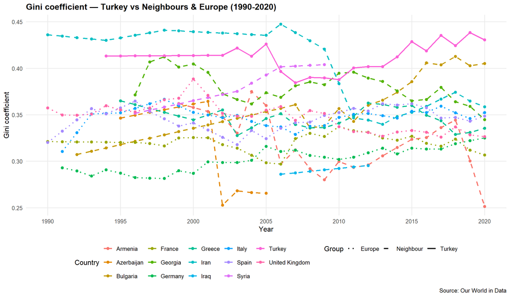

```r
analysis_data %>%
  mutate(group = ifelse(Entity == "Turkey", "Turkey",
                 ifelse(Entity %in% c("Greece", "Bulgaria", "Georgia",
                                       "Armenia", "Azerbaijan", "Iran",
                                       "Iraq", "Syria"),
                        "Neighbour", "Europe"))) %>%
  group_by(Entity) %>%
  mutate(gini = zoo::na.approx(gini, na.rm = FALSE)) %>%
  ungroup() %>%
  ggplot(aes(x = Year, y = gini, color = Entity, linetype = group)) +
  geom_line(linewidth = 1, na.rm = TRUE) +
  geom_point(data = . %>% filter(!is.na(gini)), size = 2) +
  scale_y_continuous(breaks = seq(0, 0.6, by = 0.05)) +
  scale_x_continuous(breaks = seq(1990, 2020, by = 5)) +
  scale_linetype_manual(values = c("Turkey" = "solid",
                                   "Neighbour" = "dashed",
                                   "Europe" = "dotted")) +
  labs(title   = "Gini coefficient — Turkey vs Neighbours & Europe (1990-2020)",
       x       = "Year", y = "Gini coefficient",
       color   = "Country", linetype = "Group",
       caption = "Source: Our World in Data") +
  theme_minimal(base_size = 12) +
  theme(plot.title       = element_text(face = "bold"),
        legend.position  = "bottom",
        panel.grid.minor = element_blank())
```

### 3.3.2 Turkey vs Neighbours

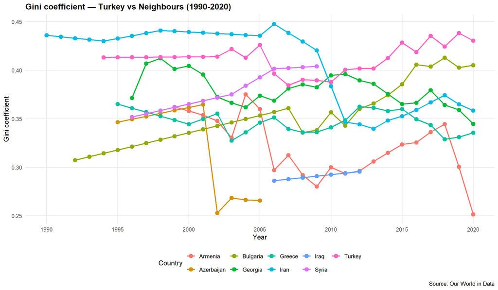

```r
analysis_data %>%
  filter(Entity %in% c("Turkey", "Greece", "Bulgaria", "Georgia",
                        "Armenia", "Azerbaijan", "Iran", "Iraq", "Syria")) %>%
  group_by(Entity) %>%
  mutate(gini = zoo::na.approx(gini, na.rm = FALSE)) %>%
  ungroup() %>%
  ggplot(aes(x = Year, y = gini, color = Entity)) +
  geom_line(linewidth = 1, na.rm = TRUE) +
  geom_point(data = . %>% filter(!is.na(gini)), size = 3) +
  scale_y_continuous(breaks = seq(0, 0.6, by = 0.05)) +
  scale_x_continuous(breaks = seq(1990, 2020, by = 5)) +
  labs(title   = "Gini coefficient — Turkey vs Neighbours (1990-2020)",
       x       = "Year", y = "Gini coefficient", color = "Country",
       caption = "Source: Our World in Data") +
  theme_minimal(base_size = 12) +
  theme(plot.title       = element_text(face = "bold"),
        legend.position  = "bottom",
        panel.grid.minor = element_blank())
```

### 3.3.3 Turkey vs Europe

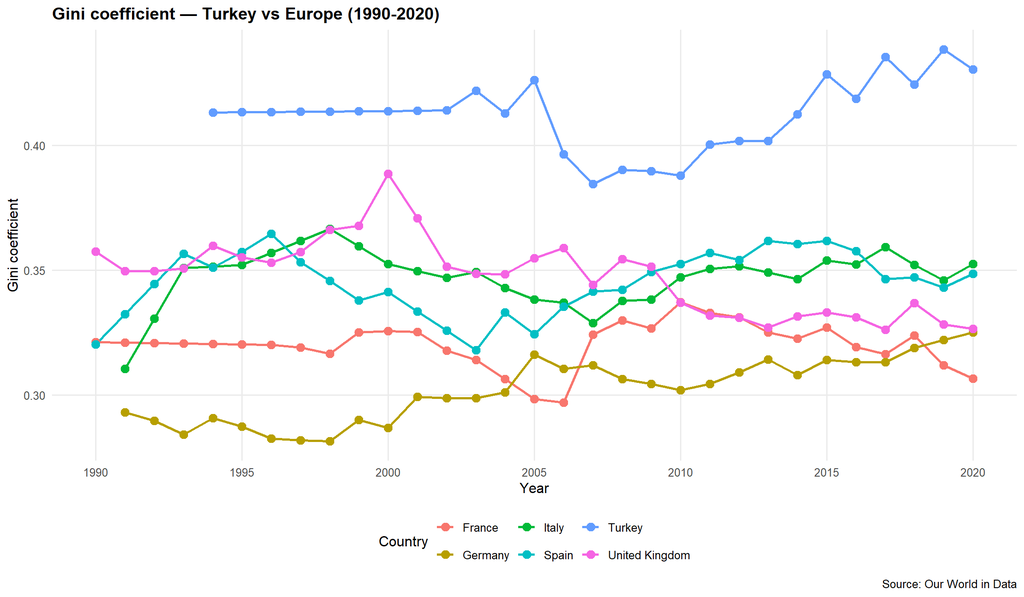

```r
analysis_data %>%
  filter(Entity %in% c("Turkey", "Spain", "United Kingdom",
                        "France", "Germany", "Italy")) %>%
  group_by(Entity) %>%
  mutate(gini = zoo::na.approx(gini, na.rm = FALSE)) %>%
  ungroup() %>%
  ggplot(aes(x = Year, y = gini, color = Entity)) +
  geom_line(linewidth = 1, na.rm = TRUE) +
  geom_point(data = . %>% filter(!is.na(gini)), size = 3) +
  scale_y_continuous(breaks = seq(0, 0.6, by = 0.05)) +
  scale_x_continuous(breaks = seq(1990, 2020, by = 5)) +
  labs(title   = "Gini coefficient — Turkey vs Europe (1990-2020)",
       x       = "Year", y = "Gini coefficient", color = "Country",
       caption = "Source: Our World in Data") +
  theme_minimal(base_size = 12) +
  theme(plot.title       = element_text(face = "bold"),
        legend.position  = "bottom",
        panel.grid.minor = element_blank())
```

## 3.4 Correlation Analysis

```r
# Overall correlations across all 14 countries
cat("=== Overall correlations ===\n")
```

```
## === Overall correlations ===
```

```r
cat("GDP ~ Schooling:", round(cor(analysis_data$gdp, analysis_data$schooling, use = "complete.obs"), 3), "\n")
```

```
## GDP ~ Schooling: 0.777
```

```r
cat("GDP ~ Gini:     ", round(cor(analysis_data$gdp, analysis_data$gini,      use = "complete.obs"), 3), "\n\n")
```

```
## GDP ~ Gini:      -0.398
```

```r
# Per-country correlations (only for countries with at least 3 data points)
cor_table <- analysis_data %>%
  group_by(Entity) %>%
  summarise(
    cor_gdp_schooling = ifelse(sum(!is.na(schooling)) >= 3,
                               round(cor(gdp, schooling, use = "complete.obs"), 3), NA),
    cor_gdp_gini      = ifelse(sum(!is.na(gini)) >= 3,
                               round(cor(gdp, gini, use = "complete.obs"), 3), NA)
  )

kable(cor_table,
      caption = "Pearson correlations per country",
      col.names = c("Country", "GDP ~ Schooling", "GDP ~ Gini")) %>%
  kable_styling(bootstrap_options = c("striped", "hover")) %>%
  row_spec(which(cor_table$Entity == "Turkey"), bold = TRUE, background = "#fff3f3")
```

Pearson correlations per country

| Country | GDP ~ Schooling | GDP ~ Gini |
| --- | --- | --- |
| Armenia | NA | -0.557 |
| Azerbaijan | NA | -0.670 |
| Bulgaria | 0.754 | 0.905 |
| France | 0.973 | 0.032 |
| Georgia | NA | -0.544 |
| Germany | 0.963 | 0.880 |
| Greece | 0.557 | -0.480 |
| Iran | 0.967 | -0.706 |
| Iraq | 0.645 | NA |
| Italy | 0.383 | -0.077 |
| Spain | 0.931 | -0.137 |
| Syria | -0.263 | 0.948 |
| Turkey | 0.972 | 0.449 |
| United Kingdom | 0.897 | -0.516 |

## 3.5 Regression Analysis

### 3.5.1 Model 1 — GDP ~ Schooling

```r
# Simple linear regression: does education predict GDP?
model_schooling <- lm(gdp ~ schooling, data = analysis_data)
summary(model_schooling)
```

```
##
## Call:
## lm(formula = gdp ~ schooling, data = analysis_data)
##
## Residuals:
##    Min     1Q Median     3Q    Max
## -23176  -7215   2199   7211  18680
##
## Coefficients:
##             Estimate Std. Error t value Pr(>|t|)
## (Intercept) -24112.2     5088.6  -4.738 9.66e-06 ***
## schooling     5779.9      533.3  10.838  < 2e-16 ***
## ---
## Signif. codes:  0 '***' 0.001 '**' 0.01 '*' 0.05 '.' 0.1 ' ' 1
##
## Residual standard error: 10420 on 77 degrees of freedom
##   (355 observations deleted due to missingness)
## Multiple R-squared:  0.604,  Adjusted R-squared:  0.5989
## F-statistic: 117.5 on 1 and 77 DF,  p-value: < 2.2e-16
```

**Interpretation:** Each additional year of schooling is associated with an average increase of **$5,780** in GDP per capita. The model explains **60.4%** of the variance in GDP (R² = 0.604). The p-value is extremely small (< 2.2e-16), confirming the statistical significance.

### 3.5.2 Model 2 — GDP ~ Gini

```r
# Simple linear regression: does inequality predict GDP?
model_gini <- lm(gdp ~ gini, data = analysis_data)
summary(model_gini)
```

```
##
## Call:
## lm(formula = gdp ~ gini, data = analysis_data)
##
## Residuals:
##    Min     1Q Median     3Q    Max
## -42850 -12146   3598  12801  25573
##
## Coefficients:
##             Estimate Std. Error t value Pr(>|t|)
## (Intercept)    94301       8723  10.811  < 2e-16 ***
## gini         -177033      24958  -7.093 1.18e-11 ***
## ---
## Signif. codes:  0 '***' 0.001 '**' 0.01 '*' 0.05 '.' 0.1 ' ' 1
##
## Residual standard error: 15280 on 267 degrees of freedom
##   (165 observations deleted due to missingness)
## Multiple R-squared:  0.1586, Adjusted R-squared:  0.1554
## F-statistic: 50.32 on 1 and 267 DF,  p-value: 1.175e-11
```

**Interpretation:** The Gini coefficient alone explains only **15.9%** of GDP variance (R² = 0.159). The negative coefficient (-177,033) suggests that higher inequality is associated with lower GDP, but the model’s explanatory power is weak.

### 3.5.3 Model 3 — GDP ~ Schooling + Gini

```r
# Multiple regression: both variables together
model_full <- lm(gdp ~ schooling + gini, data = analysis_data)
summary(model_full)
```

```
##
## Call:
## lm(formula = gdp ~ schooling + gini, data = analysis_data)
##
## Residuals:
##    Min     1Q Median     3Q    Max
## -30212  -3672   3079   5833  15756
##
## Coefficients:
##             Estimate Std. Error t value Pr(>|t|)
## (Intercept)    18140      23428   0.774 0.442571
## schooling       4272       1054   4.054 0.000184 ***
## gini          -71226      44454  -1.602 0.115667
## ---
## Signif. codes:  0 '***' 0.001 '**' 0.01 '*' 0.05 '.' 0.1 ' ' 1
##
## Residual standard error: 10110 on 48 degrees of freedom
##   (383 observations deleted due to missingness)
## Multiple R-squared:  0.4403, Adjusted R-squared:  0.417
## F-statistic: 18.88 on 2 and 48 DF,  p-value: 8.925e-07
```

**Interpretation:** When combining both variables, R² drops to **0.440** compared to Model 1. This is because many observations with Gini data are missing, reducing the sample size from 79 to 51 observations. Schooling remains highly significant (p < 0.001) while Gini is not significant (p = 0.116) when controlling for schooling.

# 4 Conclusion

This analysis compared Turkey’s GDP per capita, educational attainment, and income inequality against its neighbours and five major European economies over the period 1990–2020.

**Limitations:**

- Schooling data is only available every 5 years; linear interpolation was used for visualization.
- Gini data is highly incomplete for several countries (Azerbaijan, Iraq, Syria).
- Correlation and regression do not imply causality.
- Country-level GDP per capita masks internal regional disparities.

**Future directions:**

- Incorporate regional data (e.g. NUTS regions for Turkey and EU countries).
- Analyse gender gaps in education and their relation to inequality.
- Extend the time period to 2024 using the available GDP data.

# 5 References

- Eurostat, OECD, IMF and World Bank (2026). *GDP per capita – World Bank – In constant international-$*. Our World in Data. https://ourworldindata.org/grapher/gdp-per-capita-worldbank
- Lee, J.-W. and Lee, H. (2016). Human capital in the long run. *Journal of Development Economics*, 122, 147–169.
- R Core Team (2024). *R: A language and environment for statistical computing*. R Foundation for Statistical Computing, Vienna, Austria.
- Wickham, H. et al. (2019). Welcome to the tidyverse. *Journal of Open Source Software*, 4(43), 1686.
- Zeileis, A. and Grothendieck, G. (2005). zoo: S3 infrastructure for regular and irregular time series. *Journal of Statistical Software*, 14(6), 1–27.